# Diseños Factoriales $2^k$

Cuando hay multiple factores bajo estudio, el uso de diseños con un solo factor no son eficientes y pueden haber situaciones donde lleven a resultados equivocados. Una mejor estrategia es usar un **diseño factorial**.

En un diseño factorial las celdas consisten de todas las posibles combinaciones de los niveles de los factores bajo estudio. Y el objetivo principal es estudiar el efecto de varios factores sobre una o varias respuestas, cuando se tiene el mismo interés sobre todos los factores y existe la posibilidad de que el efecto de un factor cambie según los niveles de otros factores, esto es, que los factores interactúen, o exista *interacción*.

> El efecto de un factor es definido como el cambio en la respuesta producido por un cambio en el nivel del factor.

Empesamos estudiando el diseño factorial $2^k$, es decir, el diseño factorial en el que hay $k$ factores y todos tienen dos niveles, ya que son ampliamente usados en la practica, su interpretación es sencilla, y sirven para explorar el espacio de los factores.

### Ejemplo – Reduction of an enamine

> **(Carlson R. and Carlson J.E., 2005).** Enamines can be reduced to the corresponding saturated amine by treatment with formic acid. To determine suitabile experimental conditions for the reduction of enamines derived from camphor ($\mathrm{C_{10}H_{16}O}$), a factorial design was used to explore the reaction of the morpholine enamine. The reaction was conducted by adding formic acid drop-wise to the neat enamine at such a rate that the foaming caused by the evolution of carbon dioxide could be kept under control. The reaction is rapid and completed within a few minutes. The main product in the reaction was the desired bornylmorpholine (mixture of endo and exo isomers). There were also varying amounts of unreacted enamine and some camphor formed by hydrolysis of the enamine.

> The experimental procedure is very simple and there are only two variables to consider $X_1$, the amount of formic acid (1,1.5 mol/mol), and $X_2$, the reaction temperature (25,100$^{\circ}C$). When the reaction was complete, the resulting mixture was treated with aqueous sodium hydroxide. Then the composition of the organic layer was analysed by gas chromatography.

> The recovery of organic material was quantitative. The measured responses were: $Y_1:$ the yield of bornylmorpholine (%), $Y_2:$ the amount of unreacted enamine (%), and $Y_3:$ the amount of camphor (%).

| Exp. no. | $X_1$ | $X_2$ | $Y_1$ | Etiqueta |
| --- | --- | --- | --- | --- |
| 1 | - | - | 80.4 | (1) |
| 2 | + | - | 72.4 | a |
| 3 | - | + | 94.4 | b |
| 4 | + | + | 90.6 | ab |

Note que el nivel bajo de los factores se denota usualmente por `-` y el alto por `+`.

Calculemos los efectos para $Y_1$:

| . | Nivel bajo $X_2$ | Nivel alto $X_2$ | Promedio |
| --- | --- | --- | --- |
| Efecto de $X_1$ | $\frac{a}{n}-\frac{(1)}{n} = 72.4-80.4= -8$ | $\frac{ab}{n}-\frac{b}{n} =90.6-94.4 = -3.8$ | $(-8-3.8)/2 = -5.9$ |

Luego aumentar la cantidad de ácido fórmico causa una disminución de 5.9 % de la producción de *bornilmorfolina*.

Similarmente para $X_2:$

| . | Nivel bajo $X_1$ | Nivel alto $X_1$ | Promedio |
| --- | --- | --- | --- |
| Efecto de $X_2$ | $94.4-80.4= 14$ | $90.6-72.4 = 18.2$ | $(14+18.2)/2 = 16.1$ |

Luego aumentar la temperatura causa un aumento del 16.1% de la producción de *bornilmorfolina*.

Los efectos principales se puede usar el siguiente código en R:

```r
enamine <- data.frame(x1=gl(2,1,4,labels=c("-","+")),
                      x2=gl(2,2,4,labels=c("-","+")),
                      y=c(80.4,72.4, 94.4, 90.6))

coded <- function(x,v="-"){
  if(missing(v))
    out= x==x[1]
  else
    out= x==v
  return(2*out-1)
}

sum(coded(enamine$x1)*enamine$y)/2
```

```
## [1] 5.9
```

```r
sum(coded(enamine$x2)*enamine$y)/2
```

```
## [1] -16.1
```

```r
sum(coded(enamine$x1)*coded(enamine$x2)*enamine$y)/2
```

```
## [1] 2.1
```

## Ventajas del diseño factorial

Al examinar todas las posibles combinaciones de los niveles de los factores, el número de replicas de un nivel específico de un factor es incrementado por el producto del número de niveles de todos los otros factores en el diseño, y por lo tanto se puede obtener la misma potencia con menos réplicas.

Otra ventaja que tiene el uso de un diseño factorial sobre el uso de diseños con un solo factor es que permite el estudio de interacciones entre factores, es decir, se puede detectar situaciones en las que el efecto de un factor cambia dependiendo el nivel de otro factor.

### Ejemplo – Reduction of an enamine - cont.

```r
library(tidyverse)
```

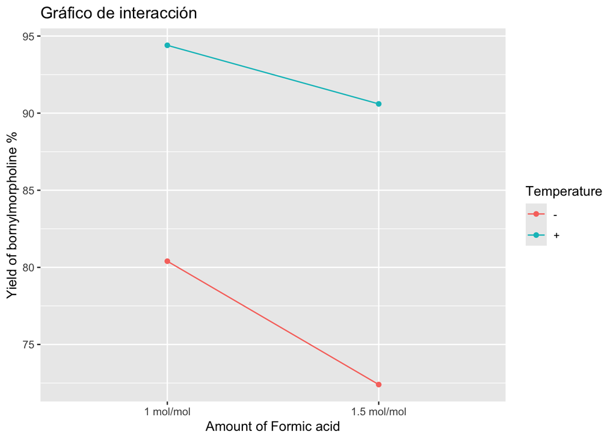

```r
enamine %>%
  ggplot() +
  aes(x = x1, y = y, color = x2) +
  geom_line(aes(group = x2)) +
  geom_point()+
  labs(title = "Gráfico de interacción",
       x = "Amount of Formic acid",
       y = "Yield of bornylmorpholine %",
       color = "Temperature") +
  scale_x_discrete(labels = c("1 mol/mol","1.5 mol/mol"))
```

### Ejemplo – Proceso químico

**(Montgomery, 2013).** An investigation into the effect of the concentration of the reactant and the amount of the catalyst on the conversion (yield) in a chemical process. The objective of the experiment was to determine if adjustments to either of these two factors would increase the yield. Let the reactant concentration be factor A and let the two levels of interest be 15 and 25 percent. The catalyst is factor B, with the high level denoting the use of 2 pounds of the catalyst and the low level denoting the use of only 1 pound. The experiment is replicated three times, so there are 12 runs.

| Factor A | Factor B | Replicas | Total |
| --- | --- | --- | --- |
| - | - | 28 25 27 | 80 |
| + | - | 36 32 32 | 100 |
| - | + | 18 19 23 | 60 |
| + | + | 31 30 29 | 90 |

```r
conversion <- data.frame(A=gl(2,3,12,c("-","+")),
                         B=gl(2,6,12,c("-","+")),
                         Yield=c(28,25,27,36,32,32,18,19,23,31,30,29) )
n <- 3
sum(coded(conversion$A)*conversion$Yield)/(2*n)
```

```
## [1] -8.333333
```

```r
sum(coded(conversion$B)*conversion$Yield)/(2*n)
```

```
## [1] 5
```

```r
sum(coded(conversion$A)*coded(conversion$B)*conversion$Yield)/(2*n)
```

```
## [1] 1.666667
```

## Diseño completamente aleatorizado con dos factores

El modelo estadístico para un diseño completamente aleatorizado con dos factores puede ser escrito así:

$$y_{ijk} = \mu_{ij} +
\epsilon_{ijk}$$

donde $i$ representa el nivel del primer factor, $j$ representa el nivel del segundo factor, y $k$ representa el número de réplica. Éste modelo es llamado el modelo de celdas medias y $\mu_{ij}$ representa la respuesta esperada en la $ij$-ésima celda. Otra manera de representar este modelo es con el modelo de efectos:

$$y_{ijk} = \mu + \alpha_i + \beta_j +
\alpha\beta_{ij} + \epsilon_{ijk}$$

En este modelo $\alpha_i$ y $\beta_j$ son los efectos principales y representan la diferencia entre el promedio marginal de todos los experimentos en el $i$-ésimo nivel del primer factor y la media global, y la diferencia entre el promedio marginal de todos los experimentos en el $j$-ésimo nivel del segundo factor y la media global, respectivamente. El efecto de la interacción, $\alpha\beta_{ij}$, representa la diferencia entre la media de la celda $\mu_{ij}$ y $\mu + \alpha_i + \beta_j$.

### Análisis de varianza

Los supuestos de este modelo son: los errores experimentales son independientes y $\epsilon_{ijk}\sim N(0,\sigma^2)$. El supuesto de independencia se garantiza si la combinación de tratamientos es asignada aleatoriamente a las unidades experimentales, y los supuestos de igualdad de varianza y normalidad pueden ser verificados como se ha hecho antes.

El análisis de varianza es usado para particonar la variabilidad de la variable respuesta debida a distintas fuentes. En el caso de un modelo de dos factores, la variabilidad se particiona en cuatro fuentes de variación: factor A, factor B, la interacción entre A y B, y el error. Es decir,

$$SST = SSA + SSB + SSAB +
SSE,$$

donde el termino de interacción mide la no aditividad de los tratamientos.

| Fuente de variación | Grados de libertad | Suma de Cuadrados | MS | F |
| --- | --- | --- | --- | --- |
| A | $a-1$ | $r b\displaystyle\sum_{i=1}^a (\overline{y}_{i\cdot\cdot} - \overline{\overline{y}})^2$ | $\frac{SSA}{a-1}$ | $\frac{MSA}{MSE}$ |
| B | $b-1$ | $r a\displaystyle\sum_{j=1}^b (\overline{y}_{\cdot j\cdot} - \overline{\overline{y}})^2$ | $\frac{SSB}{b-1}$ | $\frac{MSB}{MSE}$ |
| AB | $(a-1)(b-1)$ | $r\displaystyle\sum_{i=1}^a\sum_{j=1}^b (\overline{y}_{ij\cdot} -\overline{y}_{i\cdot\cdot}-\overline{y}_{\cdot j\cdot}+ \overline{\overline{y}})^2$ | $\frac{SSAB}{(a-1)(b-1)}$ | $\frac{MSAB}{MSE}$ |
| Error | $ab(r-1)$ | $\displaystyle\sum_{i=1}^a\sum_{j=1}^b\sum_{k=1}^{r} (y_{ijk} - \overline{y}_{ij\cdot})^2$ | $\frac{SSE}{ab(r-1)}$ |  |

En R se puede estimar el modelo usando las funciones `aov` o `lm`

```r
conversion.fit <- lm(Yield ~ A * B, conversion)
anova(conversion.fit)
```

```
## Analysis of Variance Table
##
## Response: Yield
##           Df  Sum Sq Mean Sq F value    Pr(>F)
## A          1 208.333 208.333 53.1915 8.444e-05 ***
## B          1  75.000  75.000 19.1489  0.002362 **
## A:B        1   8.333   8.333  2.1277  0.182776
## Residuals  8  31.333   3.917
## ---
## Signif. codes:  0 '***' 0.001 '**' 0.01 '*' 0.05 '.' 0.1 ' ' 1
```

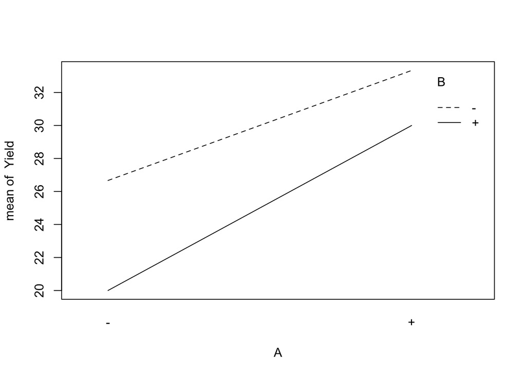

```r
with(conversion, interaction.plot(A, B, Yield))
```

```r
library(phia)
```

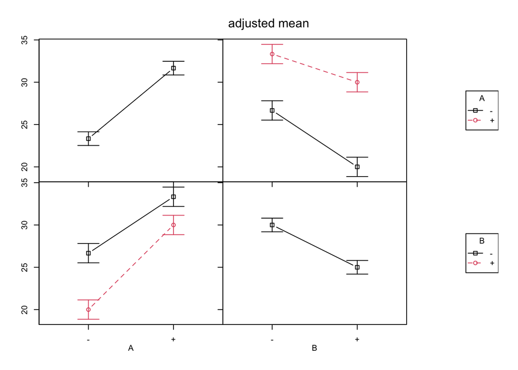

```r
plot(interactionMeans(conversion.fit))
```

### Modelo de regresión

En un análisis factorial $2^k$, es fácil expresar los resultados de un experimento en terminos de un modelo de regresión.

#### Ejemplo - Proceso químico - cont.

El modelo de regresión para el ejemplo del proceso químico (Montgomery, 2013) es

$$y = \beta_0 + \beta_1x_1 + \beta_2x_2+
\epsilon$$

donde $x_1 = \frac{\mbox{conc} - (\mbox{conc}_{+}+\mbox{conc}_{-})/2}{(\mbox{conc}_{+}-\mbox{conc}_{-})/2}$ y $x_2 = \frac{\mbox{cat} - (\mbox{cat}_{+}+\mbox{cat}_{-})/2}{(\mbox{cat}_{+}-\mbox{cat}_{-})/2}.$

```r
conversion2 <- data.frame(conc = rep(c(15,25),4, each=3),
                          cat=rep(c(1,2),each=6),
                          Yield=c(28,25,27,36,32,32,18,19,23,31,30,29) )
conversion2$A <- (conversion2$conc - 20)/5
conversion2$B <- (conversion2$cat - 1.5)/.5
conversion2.fit<-lm(Yield~A+B,data=conversion2) # Note que no se incluye interacción
summary(conversion2.fit)
```

```
##
## Call:
## lm(formula = Yield ~ A + B, data = conversion2)
##
## Residuals:
##     Min      1Q  Median      3Q     Max
## -2.8333 -1.9167  0.3333  1.8333  2.1667
##
## Coefficients:
##             Estimate Std. Error t value Pr(>|t|)
## (Intercept)  27.5000     0.3967  69.314  < 2e-16 ***
## A             4.1667     0.3967  10.502 8.16e-10 ***
## B            -2.5000     0.3967  -6.301 3.00e-06 ***
## ---
## Signif. codes:  0 '***' 0.001 '**' 0.01 '*' 0.05 '.' 0.1 ' ' 1
##
## Residual standard error: 1.944 on 21 degrees of freedom
## Multiple R-squared:  0.8772, Adjusted R-squared:  0.8655
## F-statistic:    75 on 2 and 21 DF,  p-value: 2.734e-10
```

```r
conversion2.fit2<-lm(Yield~conc+cat,data=conversion2)
summary(conversion2.fit2)
```

```
##
## Call:
## lm(formula = Yield ~ conc + cat, data = conversion2)
##
## Residuals:
##     Min      1Q  Median      3Q     Max
## -2.8333 -1.9167  0.3333  1.8333  2.1667
##
## Coefficients:
##             Estimate Std. Error t value Pr(>|t|)
## (Intercept) 18.33333    2.02302   9.062 1.06e-08 ***
## conc         0.83333    0.07935  10.502 8.16e-10 ***
## cat         -5.00000    0.79349  -6.301 3.00e-06 ***
## ---
## Signif. codes:  0 '***' 0.001 '**' 0.01 '*' 0.05 '.' 0.1 ' ' 1
##
## Residual standard error: 1.944 on 21 degrees of freedom
## Multiple R-squared:  0.8772, Adjusted R-squared:  0.8655
## F-statistic:    75 on 2 and 21 DF,  p-value: 2.734e-10
```

El modelo ajustado en terminos de las variables codificadas es

$$\widehat{y} = 27.5 + \frac{8.33}{2}x_1 +
\frac{-5.00}{2}x_2$$

y en terminos de las variables originales es

$$\widehat{y} = 18.333 +
0.833\cdot\mbox{conc} -5\cdot\mbox{cat}$$

### Superficie de respuesta

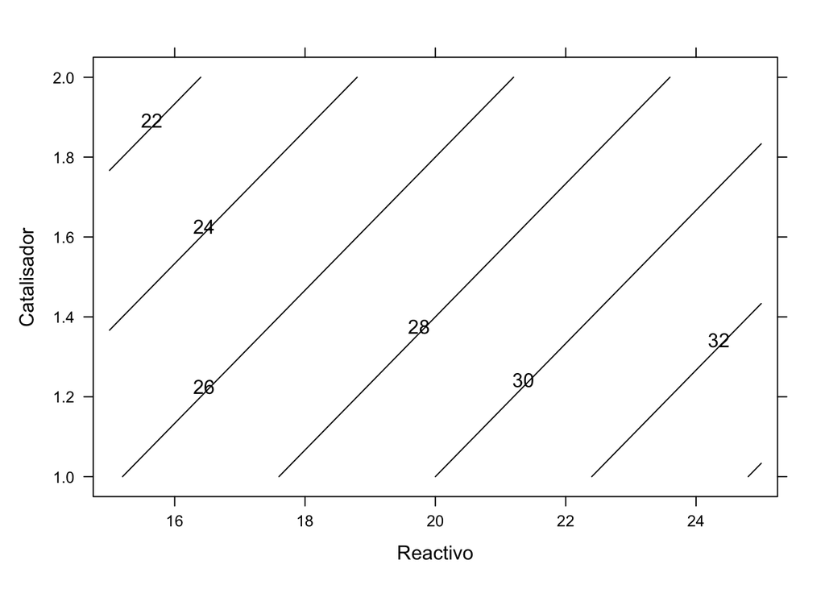

```r
library(lattice)
tmp <- list(conc=seq(15,25,by=.5),cat=seq(1,2,by=.1))
new.data <- expand.grid(tmp)
new.data$fit <- predict(conversion2.fit2,new.data)
contourplot(fit~conc+cat,new.data,xlab="Reactivo", ylab="Catalisador")
```

## Ejemplo de un diseño factorial $2^3$, “Fly ash”

**(Lawson J. y Erjavec J., 2017).** An experiment was set up to study the compressive strength of concrete made from fly ash from two different sources. The experiment factors chosen for study were:

- Fly Ash Source: The composition of the ash in different coals can be quite different. Hence, it is conceivable that the strength of the concrete could vary greatly, depending on the source of the ash. Therefore, it was important to investigate this as one of the factors.
- Water/Cement Ratio: It is important to add the appropriate amount of water, recognizing that what is appropriate may depend on the particular ash used (and its composition).
- Set-up Temperature: Since concrete is generally poured outdoors, it is important to find out if the strength of the concrete depends on the temperature at which it hardens.

The response is the 14 Day Compressive strength, mPa.

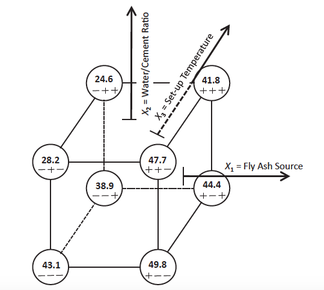

Fuente: Lawson J. y Erjavec J.,2017

```r
unos <- c(-1,1)
ceniza <- data.frame(Fuente=rep(unos,8, each=1), Prop = rep(unos,4,each=2),
                     Temp = rep(unos,2,each=4), mPa = c(43.4,50.1,27.3,47,
                    39.4,43.8,25,40.7,42.8,49.5,29.1,48.4,38.4,45,24.2,42.9))
ceniza2 <- data.frame(Fuente= gl(2,1,16,c("-","+")), Prop = gl(2,2,16,c("-","+")),
                    Temp = gl(2,4,16,c("-","+")), mPa = c(43.4,50.1,27.3,47,
                      39.4,43.8,25,40.7,42.8,49.5,29.1,48.4,38.4,45,24.2,42.9))

ceniza.fit2<-aov(mPa~Fuente*Prop*Temp,data=ceniza2)
summary(ceniza.fit2)
```

```
##                  Df Sum Sq Mean Sq F value   Pr(>F)
## Fuente            1  597.8   597.8 691.101 4.71e-09 ***
## Prop              1  287.3   287.3 332.142 8.45e-08 ***
## Temp              1   91.2    91.2 105.436 6.96e-06 ***
## Fuente:Prop       1  150.1   150.1 173.483 1.05e-06 ***
## Fuente:Temp       1    3.1     3.1   3.540   0.0967 .
## Prop:Temp         1    0.0     0.0   0.003   0.9584
## Fuente:Prop:Temp  1    0.3     0.3   0.350   0.5706
## Residuals         8    6.9     0.9
## ---
## Signif. codes:  0 '***' 0.001 '**' 0.01 '*' 0.05 '.' 0.1 ' ' 1
```

**Efectos:**

```r
ceniza.fit<-lm(mPa~Fuente*Prop*Temp,data=ceniza)
sum(ceniza$mPa*ceniza$Fuente)/8
```

```
## [1] 12.225
```

```r
sum(ceniza$mPa*ceniza$Prop)/8
```

```
## [1] -8.475
```

```r
sum(ceniza$mPa*ceniza$Prop*ceniza$Fuente)/8
```

```
## [1] 6.125
```

```r
summary(ceniza.fit)
```

```
##
## Call:
## lm(formula = mPa ~ Fuente * Prop * Temp, data = ceniza)
##
## Residuals:
##    Min     1Q Median     3Q    Max
## -1.100 -0.525  0.000  0.525  1.100
##
## Coefficients:
##                  Estimate Std. Error t value Pr(>|t|)
## (Intercept)       39.8125     0.2325 171.227 1.51e-15 ***
## Fuente             6.1125     0.2325  26.289 4.71e-09 ***
## Prop              -4.2375     0.2325 -18.225 8.45e-08 ***
## Temp              -2.3875     0.2325 -10.268 6.96e-06 ***
## Fuente:Prop        3.0625     0.2325  13.171 1.05e-06 ***
## Fuente:Temp       -0.4375     0.2325  -1.882   0.0967 .
## Prop:Temp          0.0125     0.2325   0.054   0.9584
## Fuente:Prop:Temp  -0.1375     0.2325  -0.591   0.5706
## ---
## Signif. codes:  0 '***' 0.001 '**' 0.01 '*' 0.05 '.' 0.1 ' ' 1
##
## Residual standard error: 0.9301 on 8 degrees of freedom
## Multiple R-squared:  0.9939, Adjusted R-squared:  0.9886
## F-statistic: 186.6 on 7 and 8 DF,  p-value: 3.184e-08
```

**Interacciones**

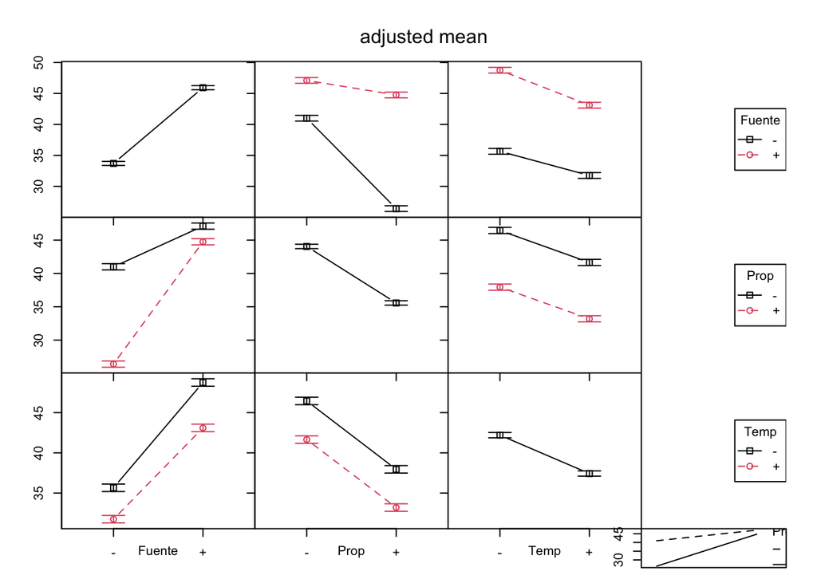

```r
plot(interactionMeans(ceniza.fit2))
with(ceniza, interaction.plot(Fuente, Prop, mPa)) # Std. Error 0.9301/sqrt(2)
```

## Procedimiento para el análisis de un diseño factorial

- Estimar los efectos de los factores
- Formular el modelo. Con replicación se puede usar el modelo completo. Sin replicación se deben seleccionar un modelo reducido
- Prueba Estadística (ANOVA)
- Refinar el modelo
- Analizar los residuales
- Interpretar los resultados

### Diseño $2^4$: Hidrogenación catalítica

**(Godawa,1984; Carlson R. and Carlson J.E., 2005).** The experiments were run to determine how four experimental variables influence the yield of tetrahydrofuran in catalytic hydrogenation of furan over a palladium catalyst. The variables and the experimental domain are $x_1:$ amount of catalyst/sustrate (0.7, 1.0 g/mol), $x_2:$ hydrogen pressure (45, 55 bar), $x_3:$ reaction temperature (75, 100 $^{\circ}C$), and $x_4:$ stirring rate (340, 475 rpm). The experimental design and yields are:

```r
hidro<- data.frame(x1=rep(unos,8,each=1),x2=rep(unos,4,each=2),x3=rep(unos,2,each=4),
                   x4=rep(unos,each=8), y = c(77.5,83.8,87.8,92.9,77.8,83.3,90.0,
                    94.1,94.1,98.3,94.2,98.3,97,99.3,98,100))
```

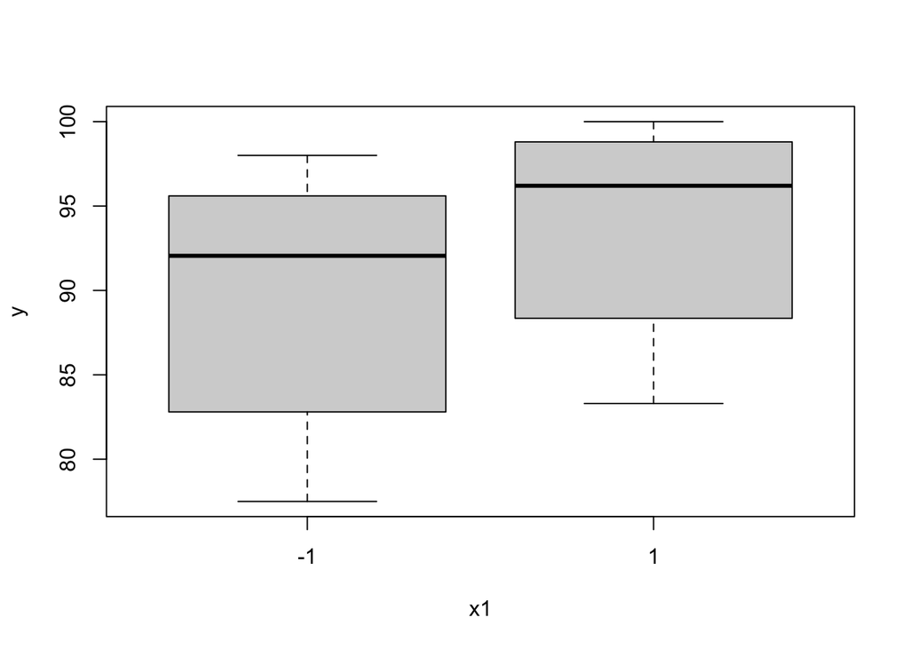

```r
# Análisis exploratorio
boxplot(y~x1, data=hidro)
```

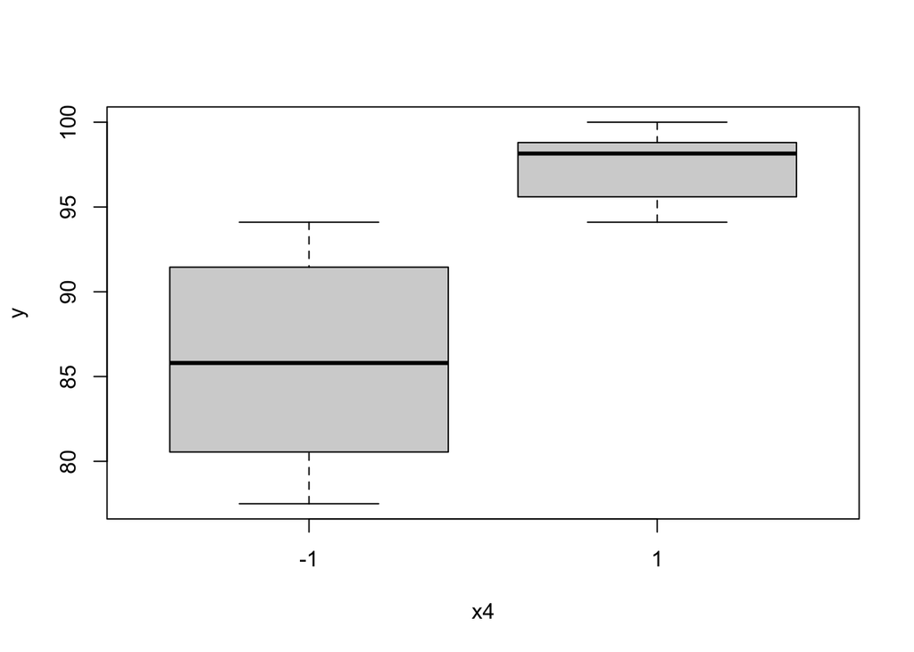

```r
boxplot(y~x4, data=hidro)
```

```r
# No hay replicaciones, luego no se pueden incluir todas las interacciones
hidro.fit <- lm(y~x1*x2*x3*x4,data=hidro)
summary(hidro.fit)
```

```
##
## Call:
## lm(formula = y ~ x1 * x2 * x3 * x4, data = hidro)
##
## Residuals:
## ALL 16 residuals are 0: no residual degrees of freedom!
##
## Coefficients:
##             Estimate Std. Error t value Pr(>|t|)
## (Intercept)  91.6500        NaN     NaN      NaN
## x1            2.1000        NaN     NaN      NaN
## x2            2.7625        NaN     NaN      NaN
## x3            0.7875        NaN     NaN      NaN
## x4            5.7500        NaN     NaN      NaN
## x1:x2        -0.1875        NaN     NaN      NaN
## x1:x3        -0.3625        NaN     NaN      NaN
## x2:x3         0.3250        NaN     NaN      NaN
## x1:x4        -0.5250        NaN     NaN      NaN
## x2:x4        -2.5375        NaN     NaN      NaN
## x3:x4         0.3875        NaN     NaN      NaN
## x1:x2:x3     -0.0250        NaN     NaN      NaN
## x1:x2:x4      0.1375        NaN     NaN      NaN
## x1:x3:x4     -0.1375        NaN     NaN      NaN
## x2:x3:x4     -0.1250        NaN     NaN      NaN
## x1:x2:x3:x4   0.0000        NaN     NaN      NaN
##
## Residual standard error: NaN on 0 degrees of freedom
## Multiple R-squared:      1,  Adjusted R-squared:    NaN
## F-statistic:   NaN on 15 and 0 DF,  p-value: NA
```

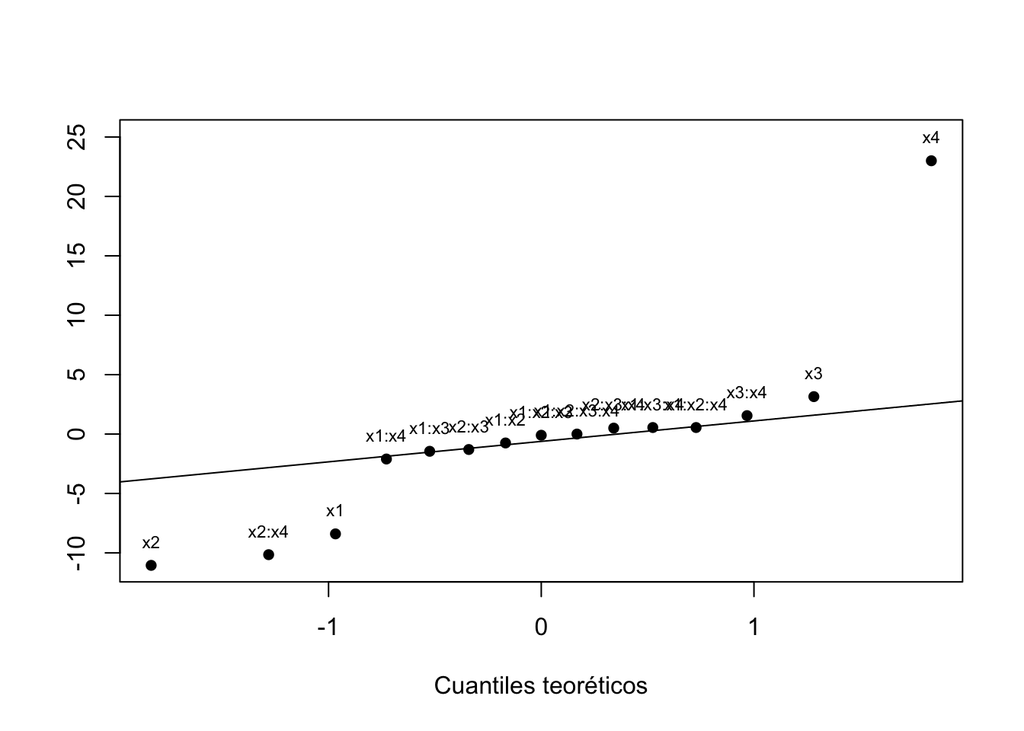

```r
# Normal QQ-plot
plot(qnorm(ppoints(15)),  sort(hidro.fit$effects)[-1], xlab="Cuantiles teoréticos",
     pch=16,ylim = c(-11,25), ylab = "")
qqline(hidro.fit$effects[-1])
text(qnorm(ppoints(15)),sort(hidro.fit$effects[-1])+2,names(sort(hidro.fit$effects[-1])),cex=.7)
```

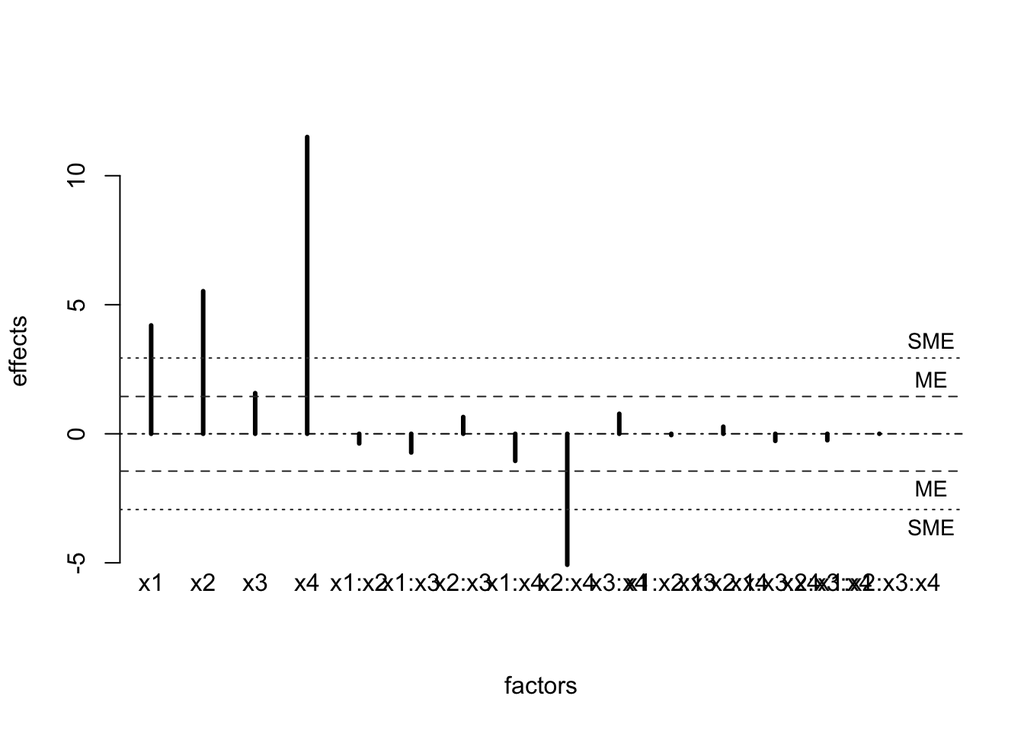

```
##    alpha      PSE       ME      SME
## 0.050000 0.562500 1.445952 2.935491
```

```r
## Lenth Plot
library(BsMD)
LenthPlot(hidro.fit) #
```

```r
# No se incluyen interacciones de tercer y cuarto orden
hidro.fit2 <- lm(y~x1+x2+x3+x4+x1:x2+x1:x3+x1:x4+x2:x3+x2:x4+x3:x4,data=hidro)
summary(hidro.fit2) # Efectos/2
```

```
##
## Call:
## lm(formula = y ~ x1 + x2 + x3 + x4 + x1:x2 + x1:x3 + x1:x4 +
##     x2:x3 + x2:x4 + x3:x4, data = hidro)
##
## Residuals:
##      1      2      3      4      5      6      7      8      9     10     11
##  0.150  0.100  0.125 -0.375 -0.425  0.175  0.150  0.100 -0.100 -0.150 -0.175
##     12     13     14     15     16
##  0.425  0.375 -0.125 -0.100 -0.150
##
## Coefficients:
##             Estimate Std. Error t value Pr(>|t|)
## (Intercept)  91.6500     0.1040 881.393 3.57e-14 ***
## x1            2.1000     0.1040  20.196 5.50e-06 ***
## x2            2.7625     0.1040  26.567 1.41e-06 ***
## x3            0.7875     0.1040   7.573 0.000637 ***
## x4            5.7500     0.1040  55.297 3.66e-08 ***
## x1:x2        -0.1875     0.1040  -1.803 0.131220
## x1:x3        -0.3625     0.1040  -3.486 0.017543 *
## x1:x4        -0.5250     0.1040  -5.049 0.003937 **
## x2:x3         0.3250     0.1040   3.126 0.026089 *
## x2:x4        -2.5375     0.1040 -24.403 2.15e-06 ***
## x3:x4         0.3875     0.1040   3.727 0.013619 *
## ---
## Signif. codes:  0 '***' 0.001 '**' 0.01 '*' 0.05 '.' 0.1 ' ' 1
##
## Residual standard error: 0.4159 on 5 degrees of freedom
## Multiple R-squared:  0.999,  Adjusted R-squared:  0.9969
## F-statistic: 488.9 on 10 and 5 DF,  p-value: 7.805e-07
```

```r
qt(.975,5)*0.4159/sqrt(16) # Intervalo de confianza
```

```
## [1] 0.2672762
```

```r
anova(hidro.fit2)
```

```
## Analysis of Variance Table
##
## Response: y
##           Df Sum Sq Mean Sq   F value    Pr(>F)
## x1         1  70.56   70.56  407.8613 5.504e-06 ***
## x2         1 122.10  122.10  705.7948 1.413e-06 ***
## x3         1   9.92    9.92   57.3555 0.0006368 ***
## x4         1 529.00  529.00 3057.8035 3.658e-08 ***
## x1:x2      1   0.56    0.56    3.2514 0.1312199
## x1:x3      1   2.10    2.10   12.1532 0.0175428 *
## x1:x4      1   4.41    4.41   25.4913 0.0039370 **
## x2:x3      1   1.69    1.69    9.7688 0.0260895 *
## x2:x4      1 103.02  103.02  595.5058 2.154e-06 ***
## x3:x4      1   2.40    2.40   13.8873 0.0136193 *
## Residuals  5   0.86    0.17
## ---
## Signif. codes:  0 '***' 0.001 '**' 0.01 '*' 0.05 '.' 0.1 ' ' 1
```

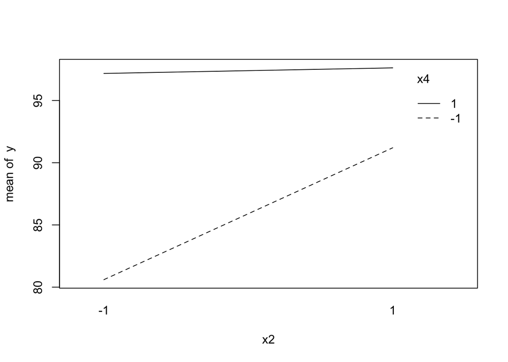

```r
with(hidro, interaction.plot(x2, x4, y)) # Gráfico de interacción
```

**Superficie de respuesta**

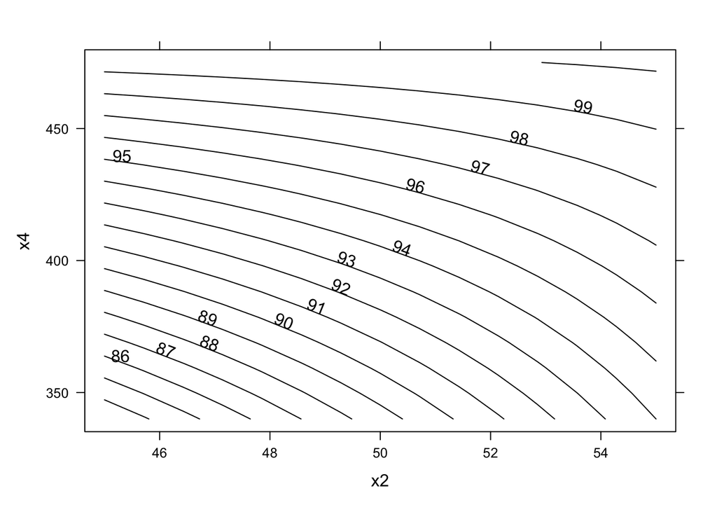

```r
hidro2<- data.frame(x1=rep(c(.7,1),8,each=1),x2=rep(c(45,55),4,each=2),
                    x3=rep(c(75,100),2,each=4), x4=rep(c(340,475),each=8),
                    y = c(77.5,83.8,87.8,92.9,77.8,83.3,90.0,
                    94.1,94.1,98.3,94.2,98.3,97,99.3,98,100))
hidro2.fit <- lm(y~x1+x2+x3+x4+x1:x2+x1:x3+x1:x4+x2:x3+x2:x4+x3:x4,data=hidro2)

tmp <- list(x1=seq(.7,1,length=15),x2=seq(45,55,length=15),
            x3 = seq(75,100,length=15), x4 = seq(340,475,length=15))

new.data <- expand.grid(tmp)

new.data$fit <- predict(hidro2.fit,new.data)

contourplot(fit~x2+x4,new.data,xlab="x2", ylab="x4",cuts=20)
```

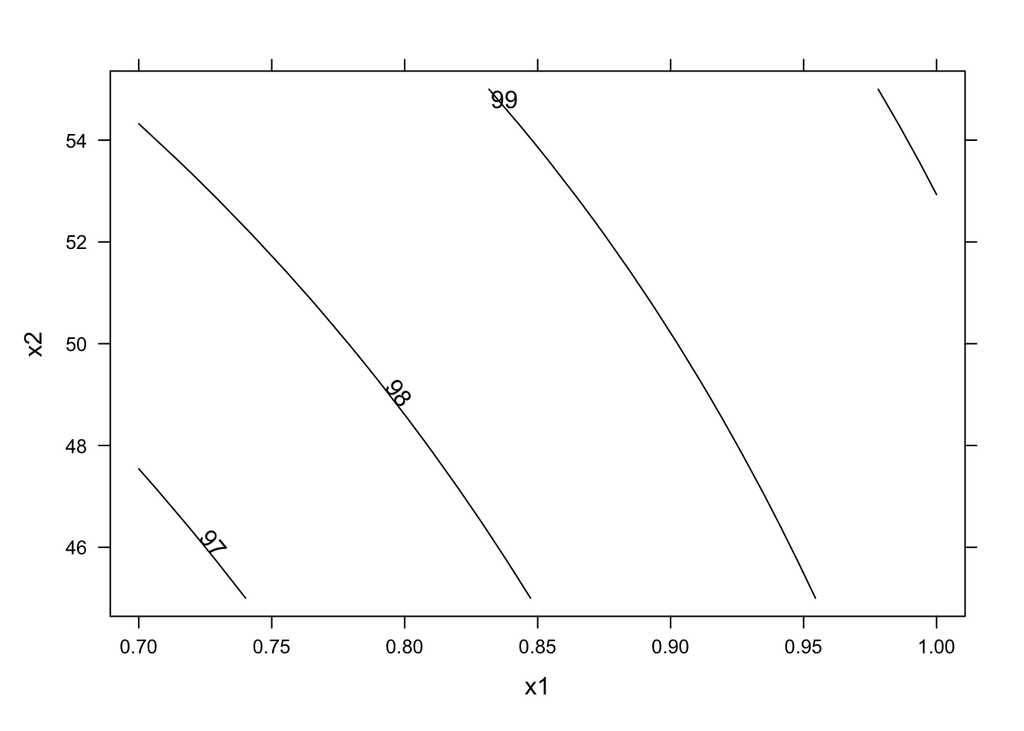

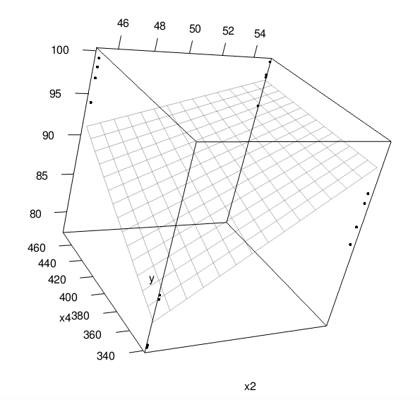

Superficie de respuesta - Hidrogenación catalítica

```r
contourplot(fit~x1+x2,new.data,xlab="x1", ylab="x2",cuts=20)
```

## Número de replicas

Sea $n_F$ el número total de experimentos en el diseño factorial $2^k$, es decir, $n_F = r\cdot 2^k$. Para el diseño factorial $2^k$ se puede mostrar que el número neceario de corridas del experimento para obtener una potencia de 0.95, cuando el nivel de significancia $\alpha=0.05$, es

$$n_F^* = \bigg(\frac{8
\sigma}{\Delta}\bigg)^2,$$

donde $\sigma$ es la desviación estándar del error experimental y $\Delta$ es el tamaño del efecto práctico.

Si el número de puntos factoriales, $2^k$, es menor que el número de corridas necesarias para la precisión deseada, entonces todo el diseño factorial debe ser replicado $r$ veces tal que $r\cdot 2^k \geq n_F^*$.

## Curvatura

Note que en situaciones cuando no hay replicaciones en todos los puntos de diseño, la única manera en que se puede estimar el error es asumiendo que las interacciones de orden alto son cero. Sin embargo, si las interacciones no son cero, el error estimado estará inflado. Luego el estimado de $s_E$ es también inflado y el valor de la estadística $t$ será pequeño. Y por lo tanto se puede dar que concluyamos que algunos efectos principales o interacciones no son significativos, cuando en en realidad sí lo son.

El análisis de datos provenientes de un diseño factorial asume que el modelo lineal describe adecuadamente los cambios en la respuesta dado los cambios en los factores. Sin embargo, con solo dos niveles en cada factor, no es posible chequear la validez de este supuesto. Además, si existen no linealidad, el diseño factorial producirá predicciones confiables solamente cerca a los puntos de diseño. En otras regiones, las predicciones no serán confiables. Esto es un gran problema, pues lo se quiere es hacer predicciones confiables sobre toda la región de experimentación.

Experimentos que incluyen replicas *en el punto central* son bastante comunes en la practica ya que permiten estimar el error y chequear que tan adecuado es el modelo lineal. Ya que al tener puntos centrales, se obtienen replicaciones que pueden ser usadas para hacer una estimación *pura* del error. Además estos puntos permiten chequear si hay curvatura comparando la respuesta observada en los puntos y el valor predecido en las condiciones centrales.

## Ejemplo

En un proceso químico un reactivo se mantiene en un recipiente para enfriarlo. Cuando alcanza la temperatura deseada, un segundo reactivo es rápidamente cargado en una mezcla acuasa/orgánica. Se llevaron a cabo experimentos para optimizar la producción. Se estudiarion dos factores: el primero fue la temperatura en el recipiente y el segundo fue la razón en la mezcla acuosa/orgánica. La respuesta fue el porcentaje de producción. Se realizaron dos replicas en las cuatro condiciones experimentales. Finalmente, dado que los factores son cuantitativos, se hicieron cuatro replicas más en el punto central.

```r
PQ <- data.frame(Temp = factor(c(gl(2,2,8),rep("0",4))),
                 Razon = factor(c(gl(2,4,8),rep("0",4))),
                 Prod=c(68.5,68.3, 72,72, 73,70,72.4, 73,74,75,74,73.5))
```

Se puede usar $C=\bar{Y}_{\mbox{centro}}-\bar{Y}_{\mbox{factorial}}$ para probar si existe alguna curvatura. El estadístio de prueba es

$$t_C = \frac{C}{S_C},$$

donde

$$S_C =
\sqrt{s_P^2\left(\frac{1}{n_c}+\frac{1}{n_F}\right)}.$$

$n_C$ y $n_F$ son el número de observaciones en el punto central y en los puntos factoriales, respectivamente. $S_P$ es el promedio ponderado de los cinco estimados de la varianza, donde los pesos son el número de observaciones menos uno.

```r
library(tidyverse)
mediasVar <- PQ %>% group_by(Temp,Razon) %>% summarize(mu = mean(Prod),v = var(Prod))
```

[output not shown]

```r
sp = sum(mediasVar$v*c(3,1,1,1,1))/7
Curv = mediasVar$mu[1] - mean(mediasVar$mu[-1])
sc = sqrt(sp*(1/4+1/8))
tc = Curv/sc
2*(1-pt(tc,7))
```

```
## [1] 0.001126661
```

Cuando la prueba de *curvatura* es significativa, como en este ejemplo, las predicciones lineales no son válidas dentro de la región experimental. Para solucionar este problema, es necesario hacer más experimentos y ajustar un modelo cuadrático.

## Diseños fraccionados

Como se mencionó anteriormente los diseños factoriales son eficientes, pero tienen el problema de que cuando el número de factores es grande, el mínimo número de experimentos es muy grande. Por esta razón, cuando se busca seleccionar, de un grupo de $k$ factores, solamente los factores importantes, se puede limitar el número de tratamientos que se exploran. Es decir, en lugar de estudiar todos las $2^k$ tratamientos, se estudia una fracción de ellos. Por ejemplo, si se tienen 6 factores, un $\frac12$ diseño fraccionado consiste de $2^{6-1}=32$ corridas.

La selección de que diseños eliminar no se puede hacer al azar, debido a que se pueden crear problemas de confusión. Es decir, no se puede distinguir a que factor corresponde el efecto.

El método de diseños fraccionados inicia con un diseño factorial completo con el número de corridas que se quiere usar y luego se le adicionan otros factores.

### Diseños fraccionados $2^{k-1}$

1. Escriba el diseño factorial $2^{k-1}$
2. Adicione el $k$-ésimo factor al diseño asignando usando los niveles de la columna con mayor orden de interacción
3. Use las $2^{k-1}$ columnas más la columna con el $k$-ésimo factor para definir el diseño

```r
unos<- c(-1,1)
d41 <- data.frame(x1=rep(unos,4),x2=rep(unos,2,each=2),x3=rep(unos,each=4))
d41$x12 <- d41$x1*d41$x2
d41$x13 <- d41$x1*d41$x3
d41$x23 <- d41$x2*d41$x3
d41$x4 <- d41$x1*d41$x2*d41$x3
d41[,c("x1","x2","x3","x4")]
```

```
##   x1 x2 x3 x4
## 1 -1 -1 -1 -1
## 2  1 -1 -1  1
## 3 -1  1 -1  1
## 4  1  1 -1 -1
## 5 -1 -1  1  1
## 6  1 -1  1 -1
## 7 -1  1  1 -1
## 8  1  1  1  1
```

### Patrón de confusión

El generador del diseño que se definió anteriormente es
$$4 = 123$$
Usando este generador se puede encontrar el patrón de confusión:
$$4^2=123\cdot 4 \Rightarrow I = 1234. \qquad
24\cdot I = 24\cdot 1234 \Rightarrow 24 = 12^234^2 = 13$$

#### Ejemplo – Pressure Vessel (Montgomery, 2013)

A chemical product is produced in a pressure vessel. A factorial experiment is carried out in the pilot plant to study the factors thought to influence the filtration rate of this product. The four factors are temperature ($A$), pressure ($B$), concentration of formaldehyde ($C$), and stirring rate ($D$). Each factor is present at two levels. The process engineer is interested in maximizing the filtration rate. Current process conditions give filtration rates of around 75 gal/h. The process also currently uses the concentration of formaldehyde, factor C, at the high level. The engineer would like to reduce the formaldehyde concentration as much as possible but has been unable to do so because it always results in lower filtration rates.

```r
unos <- c(-1,1)
filtracion<- data.frame(x1=rep(unos,8,each=1),x2=rep(unos,4,each=2),
                        x3=rep(unos,2,each=4),x4=rep(unos,each=8),
                        y = c(45,71,48,65,68,60,80,65,43,100,45,
                              104,75,86,70,96))
# efectos
sum(filtracion$y*filtracion$x1)/8
```

```
## [1] 21.625
```

```r
sum(filtracion$y*filtracion$x2)/8
```

```
## [1] 3.125
```

```r
filtracion.fit <- lm(y~x1*x2*x3*x4,data=filtracion)
summary(filtracion.fit)
```

```
##
## Call:
## lm(formula = y ~ x1 * x2 * x3 * x4, data = filtracion)
##
## Residuals:
## ALL 16 residuals are 0: no residual degrees of freedom!
##
## Coefficients:
##             Estimate Std. Error t value Pr(>|t|)
## (Intercept)  70.0625        NaN     NaN      NaN
## x1           10.8125        NaN     NaN      NaN
## x2            1.5625        NaN     NaN      NaN
## x3            4.9375        NaN     NaN      NaN
## x4            7.3125        NaN     NaN      NaN
## x1:x2         0.0625        NaN     NaN      NaN
## x1:x3        -9.0625        NaN     NaN      NaN
## x2:x3         1.1875        NaN     NaN      NaN
## x1:x4         8.3125        NaN     NaN      NaN
## x2:x4        -0.1875        NaN     NaN      NaN
## x3:x4        -0.5625        NaN     NaN      NaN
## x1:x2:x3      0.9375        NaN     NaN      NaN
## x1:x2:x4      2.0625        NaN     NaN      NaN
## x1:x3:x4     -0.8125        NaN     NaN      NaN
## x2:x3:x4     -1.3125        NaN     NaN      NaN
## x1:x2:x3:x4   0.6875        NaN     NaN      NaN
##
## Residual standard error: NaN on 0 degrees of freedom
## Multiple R-squared:      1,  Adjusted R-squared:    NaN
## F-statistic:   NaN on 15 and 0 DF,  p-value: NA
```

```r
anova(filtracion.fit)
```

```
## Analysis of Variance Table
##
## Response: y
##             Df  Sum Sq Mean Sq F value Pr(>F)
## x1           1 1870.56 1870.56     NaN    NaN
## x2           1   39.06   39.06     NaN    NaN
## x3           1  390.06  390.06     NaN    NaN
## x4           1  855.56  855.56     NaN    NaN
## x1:x2        1    0.06    0.06     NaN    NaN
## x1:x3        1 1314.06 1314.06     NaN    NaN
## x2:x3        1   22.56   22.56     NaN    NaN
## x1:x4        1 1105.56 1105.56     NaN    NaN
## x2:x4        1    0.56    0.56     NaN    NaN
## x3:x4        1    5.06    5.06     NaN    NaN
## x1:x2:x3     1   14.06   14.06     NaN    NaN
## x1:x2:x4     1   68.06   68.06     NaN    NaN
## x1:x3:x4     1   10.56   10.56     NaN    NaN
## x2:x3:x4     1   27.56   27.56     NaN    NaN
## x1:x2:x3:x4  1    7.56    7.56     NaN    NaN
## Residuals    0    0.00     NaN
```

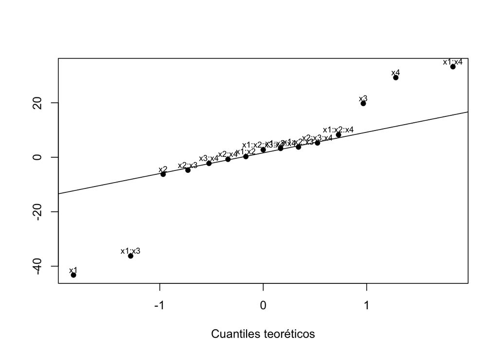

```r
plot(qnorm(ppoints(15)),  sort(filtracion.fit$effects)[-1], xlab="Cuantiles teoréticos",
     pch=16, ylab = "")

qqline(filtracion.fit$effects[-1])
text(qnorm(ppoints(15)),sort(filtracion.fit$effects[-1])+2,names(sort(filtracion.fit$effects[-1])),cex=.7)
```

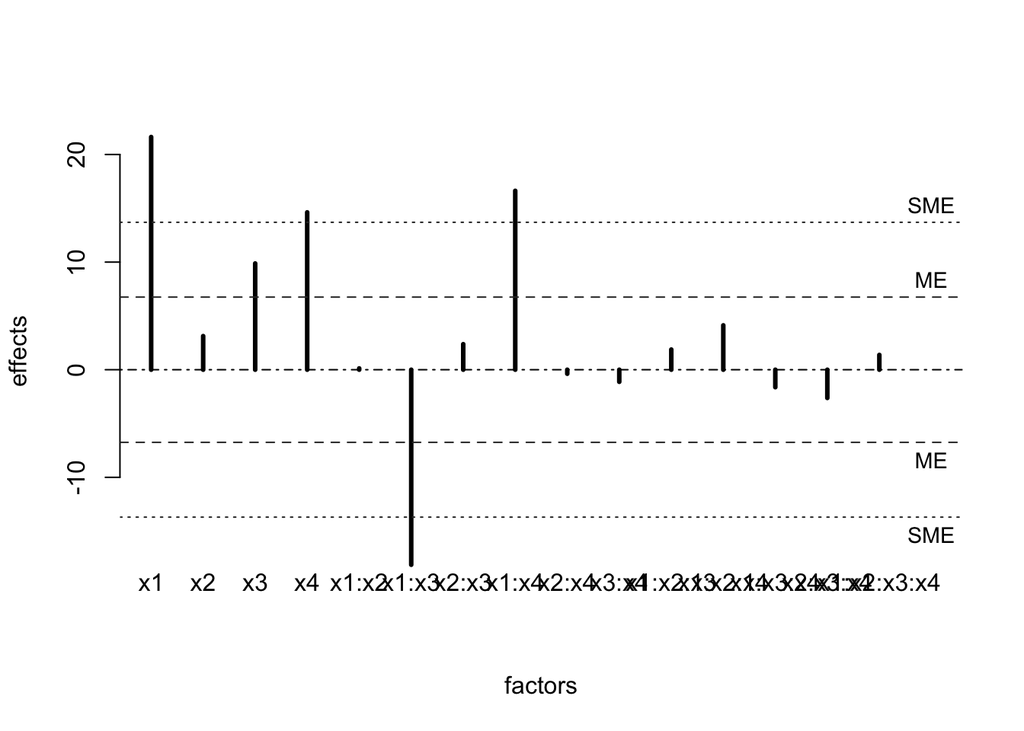

```
##     alpha       PSE        ME       SME
##  0.050000  2.625000  6.747777 13.698960
```

```r
LenthPlot(filtracion.fit)
```

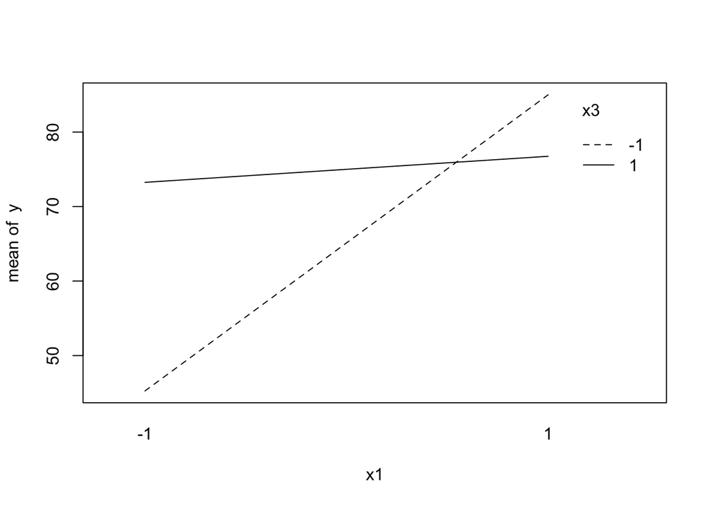

```r
with(filtracion, interaction.plot(x1, x3, y))
```

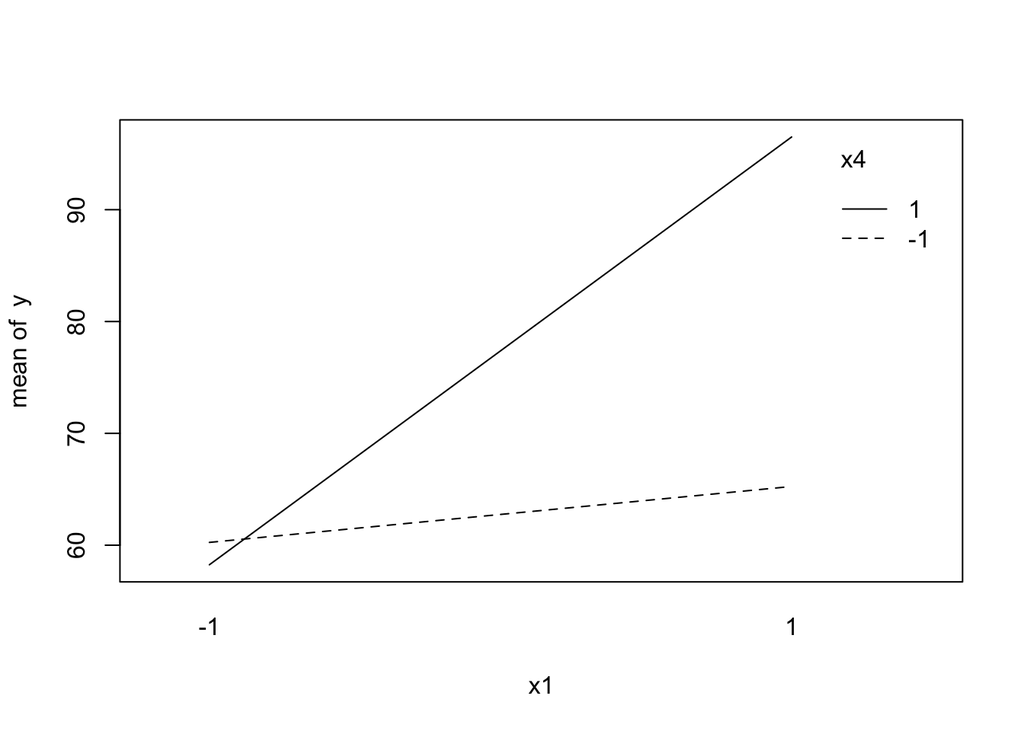

```r
with(filtracion, interaction.plot(x1, x4, y))
```

Let’s see what have happened if a half-fraction of the $2^4$ design had been run instead of the full factorial.

```r
filtro <- filtracion[c(1,10,11,4,13,6,7,16),]
sum(filtro$y*filtro$x1)/4
```

```
## [1] 19
```

```r
sum(filtro$y*filtro$x4)/4
```

```
## [1] 16.5
```

```r
filtro.fit0 <- lm(y~x1*x2*x3*x4,data=filtro)
summary(filtro.fit0)
```

```
##
## Call:
## lm(formula = y ~ x1 * x2 * x3 * x4, data = filtro)
##
## Residuals:
## ALL 8 residuals are 0: no residual degrees of freedom!
##
## Coefficients: (8 not defined because of singularities)
##             Estimate Std. Error t value Pr(>|t|)
## (Intercept)    70.75        NaN     NaN      NaN
## x1              9.50        NaN     NaN      NaN
## x2              0.75        NaN     NaN      NaN
## x3              7.00        NaN     NaN      NaN
## x4              8.25        NaN     NaN      NaN
## x1:x2          -0.50        NaN     NaN      NaN
## x1:x3          -9.25        NaN     NaN      NaN
## x2:x3           9.50        NaN     NaN      NaN
## x1:x4             NA         NA      NA       NA
## x2:x4             NA         NA      NA       NA
## x3:x4             NA         NA      NA       NA
## x1:x2:x3          NA         NA      NA       NA
## x1:x2:x4          NA         NA      NA       NA
## x1:x3:x4          NA         NA      NA       NA
## x2:x3:x4          NA         NA      NA       NA
## x1:x2:x3:x4       NA         NA      NA       NA
##
## Residual standard error: NaN on 0 degrees of freedom
## Multiple R-squared:      1,  Adjusted R-squared:    NaN
## F-statistic:   NaN on 7 and 0 DF,  p-value: NA
```

```r
filtro.fit1 <- lm(y~x1*(x2+x3+x4),data=filtro)
summary(filtro.fit1)
```

```
##
## Call:
## lm(formula = y ~ x1 * (x2 + x3 + x4), data = filtro)
##
## Residuals:
## ALL 8 residuals are 0: no residual degrees of freedom!
##
## Coefficients:
##             Estimate Std. Error t value Pr(>|t|)
## (Intercept)    70.75        NaN     NaN      NaN
## x1              9.50        NaN     NaN      NaN
## x2              0.75        NaN     NaN      NaN
## x3              7.00        NaN     NaN      NaN
## x4              8.25        NaN     NaN      NaN
## x1:x2          -0.50        NaN     NaN      NaN
## x1:x3          -9.25        NaN     NaN      NaN
## x1:x4           9.50        NaN     NaN      NaN
##
## Residual standard error: NaN on 0 degrees of freedom
## Multiple R-squared:      1,  Adjusted R-squared:    NaN
## F-statistic:   NaN on 7 and 0 DF,  p-value: NA
```

```r
filtro.fit2 <- lm(y~x1*(x3+x4),data=filtro)
summary(filtro.fit2)
```

```
##
## Call:
## lm(formula = y ~ x1 * (x3 + x4), data = filtro)
##
## Residuals:
##     1    10    11     4    13     6     7    16
## -1.25 -0.25  1.25  0.25 -1.25 -0.25  1.25  0.25
##
## Coefficients:
##             Estimate Std. Error t value Pr(>|t|)
## (Intercept)  70.7500     0.6374  111.00 8.11e-05 ***
## x1            9.5000     0.6374   14.90  0.00447 **
## x3            7.0000     0.6374   10.98  0.00819 **
## x4            8.2500     0.6374   12.94  0.00592 **
## x1:x3        -9.2500     0.6374  -14.51  0.00471 **
## x1:x4         9.5000     0.6374   14.90  0.00447 **
## ---
## Signif. codes:  0 '***' 0.001 '**' 0.01 '*' 0.05 '.' 0.1 ' ' 1
##
## Residual standard error: 1.803 on 2 degrees of freedom
## Multiple R-squared:  0.9979, Adjusted R-squared:  0.9926
## F-statistic: 188.6 on 5 and 2 DF,  p-value: 0.005282
```

### Diseños fraccionados $2^{k-2}$

```r
unos<- c(-1,1)
d52 <- data.frame(x1=rep(unos,4),x2=rep(unos,2,each=2),x3=rep(unos,each=4))
d52$x4 <- d52$x1*d52$x2
d52$x5 <- d52$x1*d52$x3
d52$x23 <- d52$x2*d52$x3
d52$x123 <- d52$x1*d52$x2*d52$x3
d52[,c("x1","x2","x3","x4","x5")]
```

```
##   x1 x2 x3 x4 x5
## 1 -1 -1 -1  1  1
## 2  1 -1 -1 -1 -1
## 3 -1  1 -1 -1  1
## 4  1  1 -1  1 -1
## 5 -1 -1  1  1 -1
## 6  1 -1  1 -1  1
## 7 -1  1  1 -1 -1
## 8  1  1  1  1  1
```

$$4 = 12 \qquad 5 = 13 \Rightarrow I = 124
= 135 = 2345$$

#### Ejemplo - Impurezas ($2^{7-3}$)

```r
unos<- c(-1,1)
d74 <- data.frame(x1=rep(unos,8),x2=rep(unos,4,each=2),x3=rep(unos,2,each=4),
                  x4=rep(unos,each=8))
d74$x5 <- d74$x1*d74$x2*d74$x3
d74$x6 <- d74$x2*d74$x3*d74$x4
d74$x7 <- d74$x1*d74$x3*d74$x4
d74[,c("x1","x2","x3","x4","x5","x6","x7")]
```

```
##    x1 x2 x3 x4 x5 x6 x7
## 1  -1 -1 -1 -1 -1 -1 -1
## 2   1 -1 -1 -1  1 -1  1
## 3  -1  1 -1 -1  1  1 -1
## 4   1  1 -1 -1 -1  1  1
## 5  -1 -1  1 -1  1  1  1
## 6   1 -1  1 -1 -1  1 -1
## 7  -1  1  1 -1 -1 -1  1
## 8   1  1  1 -1  1 -1 -1
## 9  -1 -1 -1  1 -1  1  1
## 10  1 -1 -1  1  1  1 -1
## 11 -1  1 -1  1  1 -1  1
## 12  1  1 -1  1 -1 -1 -1
## 13 -1 -1  1  1  1 -1 -1
## 14  1 -1  1  1 -1 -1  1
## 15 -1  1  1  1 -1  1 -1
## 16  1  1  1  1  1  1  1
```

```r
d74$y <- c(2.6,.89,1.82,.49,1.83,1.26,2.23,1.98,0.67,.07,.51,.72,1.61,.08,.53,.16)
d74.fit <- lm(y~x1*(x2+x3+x4+x5+x6+x7),d74)
```